# CSE-300 project

```python
import pandas as pd
import numpy as np
import matplotlib.pyplot as plt
import ipywidgets as widgets
from sklearn.cluster import KMeans
from sklearn.preprocessing import StandardScaler
```

```python
# Read child mortality dataset
df_child = pd.read_csv('child-mortality-by-income-level-of-country.csv')

df_gdp = pd.read_csv('imf_gdp_per_capita.csv', encoding='latin1')

df_who = pd.read_csv('WHO_health_expenditure_per_capita.csv', encoding='latin1')

df_income_class = pd.read_excel('income_classification.xlsx')
```

```python
# Filtering out the rows with years between 2000 and 2019 (inclusive) from the original dataframe
df_child_filtered = df_child[(df_child['Year'] >= 2000) & (df_child['Year'] <= 2019)].reset_index(drop=True)

df_child_filtered = df_child_filtered.rename(columns={'Mortality rate, under-5 (per 1,000 live births)': 'Mortality', 'Entity':'Countries'})

df_child_filtered['Mortality'] = pd.to_numeric(df_child_filtered['Mortality'], errors='coerce')

# Display the top 5 rows of the filtered and modified dataframe
df_child_filtered.head(10)
```

|  | Countries | Code | Year | Mortality |
| --- | --- | --- | --- | --- |
| 0 | Afghanistan | AFG | 2000 | 12.92 |
| 1 | Afghanistan | AFG | 2001 | 12.52 |
| 2 | Afghanistan | AFG | 2002 | 12.11 |
| 3 | Afghanistan | AFG | 2003 | 11.69 |
| 4 | Afghanistan | AFG | 2004 | 11.26 |
| 5 | Afghanistan | AFG | 2005 | 10.84 |
| 6 | Afghanistan | AFG | 2006 | 10.41 |
| 7 | Afghanistan | AFG | 2007 | 9.99 |
| 8 | Afghanistan | AFG | 2008 | 9.57 |
| 9 | Afghanistan | AFG | 2009 | 9.17 |

# Child Mortality Dataset Filtering

- Data from the years 2000 to 2019 (inclusive) has been included.
- Columns have been renamed for improved readability.
- Mortality column values have been converted into numerical format.

```python
# Renaming the column 'GDP per capita, current prices\n (U.S. dollars per capita)' to 'Countries'
df_gdp_filtered = df_gdp.rename(columns={'GDP per capita, current prices\n (U.S. dollars per capita)':'Countries'})

for col in df_gdp_filtered.columns[1:]:
    df_gdp_filtered[col] = pd.to_numeric(df_gdp_filtered[col], errors='coerce')

# Display the top 5 rows of the filtered and modified dataframe
df_gdp_filtered.head(10)
```

|  | Countries | 2000 | 2001 | 2002 | 2003 | 2004 | 2005 | 2006 | 2007 | 2008 | ... | 2010 | 2011 | 2012 | 2013 | 2014 | 2015 | 2016 | 2017 | 2018 | 2019 |
| --- | --- | --- | --- | --- | --- | --- | --- | --- | --- | --- | --- | --- | --- | --- | --- | --- | --- | --- | --- | --- | --- |
| 0 | Afghanistan | NaN | NaN | 233.433 | 233.755 | 254.259 | 294.396 | 320.674 | 381.502 | 447.746 | ... | 631.490 | 714.700 | 784.611 | 754.402 | 746.922 | 705.597 | 617.126 | 635.789 | 582.323 | 586.204 |
| 1 | Albania | 1127.640 | 1283.573 | 1425.125 | 1846.119 | 2373.580 | 2673.773 | 2972.745 | 3595.053 | 4370.562 | ... | 4097.833 | 4439.890 | 4248.909 | 4415.600 | 4584.919 | 3953.611 | 4124.405 | 4525.887 | 5257.714 | 5345.058 |
| 2 | Algeria | 1794.695 | 1768.577 | 1806.860 | 2128.386 | 2636.479 | 3141.027 | 3508.959 | 3986.564 | 4943.502 | ... | 4480.719 | 5447.600 | 5575.653 | 5477.055 | 5466.329 | 4153.322 | 3918.941 | 4014.707 | 4106.997 | 3953.402 |
| 3 | Andorra | NaN | NaN | NaN | NaN | NaN | NaN | NaN | NaN | NaN | ... | 49030.229 | 51957.313 | 45713.970 | 45630.195 | 46299.282 | 38877.485 | 39595.317 | 40017.741 | 42229.903 | 40688.491 |
| 4 | Angola | 681.129 | 645.145 | 872.658 | 982.806 | 1254.696 | 1900.724 | 2597.964 | 3121.349 | 4081.718 | ... | 3586.664 | 4608.155 | 5083.827 | 5228.511 | 5371.217 | 4130.930 | 3468.518 | 4039.300 | 3240.858 | 2612.246 |
| 5 | Antigua and Barbuda | 10931.312 | 10411.422 | 10485.776 | 10921.845 | 11613.334 | 12785.872 | 14317.674 | 16060.877 | 16574.257 | ... | 13574.440 | 13295.364 | 13825.317 | 13414.902 | 13980.610 | 14728.706 | 15588.535 | 15686.747 | 16889.792 | 17370.041 |
| 6 | Argentina | 8638.543 | 8085.356 | 2997.621 | 3761.088 | 4314.098 | 5163.550 | 5976.082 | 7315.726 | 9146.790 | ... | 10412.974 | 12787.806 | 13889.792 | 14488.829 | 13208.831 | 14895.316 | 12772.868 | 14618.327 | 11786.433 | 10054.023 |
| 7 | Armenia | 620.638 | 692.287 | 779.122 | 923.387 | 1180.399 | 1628.063 | 2128.151 | 3079.031 | 3913.436 | ... | 3121.778 | 3417.172 | 3575.529 | 3732.035 | 3889.004 | 3529.026 | 3524.000 | 3868.906 | 4195.963 | 4596.861 |
| 8 | Aruba | 20681.137 | 20740.206 | 21307.261 | 21949.392 | 23700.571 | 24171.995 | 24845.660 | 26736.575 | 28172.075 | ... | 24093.087 | 25712.454 | 25119.736 | 25813.523 | 26129.727 | 27458.227 | 27441.582 | 28440.093 | 30082.212 | 31096.315 |
| 9 | Australia | 20895.367 | 19486.698 | 21692.196 | 27288.855 | 32852.825 | 36232.385 | 37948.951 | 45180.943 | 49194.235 | ... | 56577.949 | 67270.220 | 68449.591 | 65200.823 | 61616.044 | 51412.407 | 51815.345 | 55804.163 | 56352.938 | 54289.066 |

10 rows × 21 columns

# GDP per capita Dataset Filtering

- Columns have been renamed for improved readability.
- Values in the all the year columns have been converted into numerical format.

```python
# Filtering out rows with index 1 onwards and resetting the index
df_who_filtered = df_who.loc[1:].reset_index(drop=True)

df_who_filtered = df_who_filtered.drop(columns=['Unnamed: 2'])

df_who_filtered = df_who_filtered.sort_values(by='Countries').reset_index(drop=True)

for col in df_who_filtered.columns[2:]:
    df_who_filtered[col] = pd.to_numeric(df_who_filtered[col], errors='coerce')

# Display the top 5 rows of the filtered and modified dataframe
df_who_filtered.head(5)
```

|  | Countries | Indicators | 2000 | 2001 | 2002 | 2003 | 2004 | 2005 | 2006 | 2007 | ... | 2010 | 2011 | 2012 | 2013 | 2014 | 2015 | 2016 | 2017 | 2018 | 2019 |
| --- | --- | --- | --- | --- | --- | --- | --- | --- | --- | --- | --- | --- | --- | --- | --- | --- | --- | --- | --- | --- | --- |
| 0 | Afghanistan | Current Health Expenditure (CHE) per Capita in... | NaN | NaN | 17.0 | 18.0 | 21.0 | 25.0 | 29.0 | 33.0 | ... | 47.0 | 52.0 | 53.0 | 56.0 | 60.0 | 60.0 | 61.0 | 67.0 | 71.0 | 74.0 |
| 1 | Albania | Current Health Expenditure (CHE) per Capita in... | 65.0 | 74.0 | 79.0 | 111.0 | 142.0 | 155.0 | 168.0 | 205.0 | ... | 255.0 | 272.0 | 260.0 | 278.0 | 295.0 | NaN | NaN | NaN | NaN | NaN |
| 2 | Algeria | Current Health Expenditure (CHE) per Capita in... | 62.0 | 67.0 | 67.0 | 76.0 | 93.0 | 101.0 | 117.0 | 152.0 | ... | 230.0 | 288.0 | 337.0 | 333.0 | 361.0 | 293.0 | 262.0 | 260.0 | 258.0 | 251.0 |
| 3 | Andorra | Current Health Expenditure (CHE) per Capita in... | NaN | NaN | NaN | NaN | NaN | NaN | NaN | NaN | ... | NaN | NaN | NaN | NaN | NaN | NaN | NaN | NaN | NaN | NaN |
| 4 | Angola | Current Health Expenditure (CHE) per Capita in... | 13.0 | 29.0 | 29.0 | 35.0 | 50.0 | 54.0 | 70.0 | 93.0 | ... | 97.0 | 122.0 | 122.0 | 143.0 | 131.0 | 108.0 | 94.0 | 113.0 | 84.0 | 69.0 |

5 rows × 22 columns

# Health Expenditure Dataset Filtering

- Empty rows and columns are filtered out.
- Sorted in ascending order by country names.
- Values in the all the year columns have been converted into numerical format.

```python
# Display the df_income_class dataframe

display(df_income_class)
```

|  | Data for calendar year : | 2000 | 2001 | 2002 | 2003 | 2004 | 2005 | 2006 | 2007 | 2008 | ... | 2010 | 2011 | 2012 | 2013 | 2014 | 2015 | 2016 | 2017 | 2018 | 2019 |
| --- | --- | --- | --- | --- | --- | --- | --- | --- | --- | --- | --- | --- | --- | --- | --- | --- | --- | --- | --- | --- | --- |
| 0 | Low income (L) | <= 755 | <= 745 | <= 735 | <= 765 | <= 825 | <= 875 | <= 905 | <= 935 | <= 975 | ... | <= 1,005 | <= 1,025 | <= 1,035 | <= 1,045 | <= 1,045 | <= 1,025 | <= 1,005 | <= 995 | <= 1,025 | <= 1,035 |
| 1 | Lower middle income (LM) | 756-2,995 | 746-2,975 | 736-2,935 | 766-3,035 | 826-3,255 | 876-3,465 | 906-3,595 | 936-3,705 | 976-3,855 | ... | 1,006-3,975 | 1,026-4,035 | 1,036-4,085 | 1,046-4,125 | 1,046-4,125 | 1,026-4,035 | 1,006-3,955 | 996-3,895 | 1,026-3,995 | 1,036 - 4,045 |
| 2 | Upper middle income (UM) | 2,996-9,265 | 2,976-9,205 | 2,936-9,075 | 3,036-9,385 | 3,256-10,065 | 3,466-10,725 | 3,596-11,115 | 3,706-11,455 | 3,856-11,905 | ... | 3,976-12,275 | 4,036-12,475 | 4,086-12,615 | 4,126-12,745 | 4,126-12,735 | 4,036-12,475 | 3,956-12,235 | 3,896-12,055 | 3,996-12,375 | 4,046 - 12,535 |
| 3 | High income (H) | > 9,265 | > 9,205 | > 9,075 | > 9,385 | > 10,065 | > 10,725 | > 11,115 | > 11,455 | > 11,905 | ... | > 12,275 | > 12,475 | > 12,615 | > 12,745 | > 12,735 | > 12,475 | > 12,235 | > 12,055 | > 12,375 | > 12,535 |

4 rows × 21 columns

```python
# Creating a new DataFrame df_income_class_filtered
df_income_class_filtered = df_income_class.copy()

for col in df_income_class.columns[1:]:
    for row, income_class in enumerate(['Low', 'Lower middle', 'Upper middle', 'High']):
        values = df_income_class[col][row].split('<=' if row == 0 else '-' if row in [1, 2] else '> ')

        cleaned_values = [int(value.replace(',', '')) if value else 0 for value in values]


        if row == 3:
            cleaned_values = [cleaned_values[1] + 1, 1000000000]

        df_income_class_filtered.at[row, col] = cleaned_values

df_income_class_filtered = df_income_class_filtered.rename(columns={'Data for calendar year :': 'Income Class'})

df_income_class_filtered['Income Class'] = ['Low', 'Lower Middle', 'Upper Middle', 'High']

# Display the resulting DataFrame
display(df_income_class_filtered)
```

|  | Income Class | 2000 | 2001 | 2002 | 2003 | 2004 | 2005 | 2006 | 2007 | 2008 | ... | 2010 | 2011 | 2012 | 2013 | 2014 | 2015 | 2016 | 2017 | 2018 | 2019 |
| --- | --- | --- | --- | --- | --- | --- | --- | --- | --- | --- | --- | --- | --- | --- | --- | --- | --- | --- | --- | --- | --- |
| 0 | Low | [0, 755] | [0, 745] | [0, 735] | [0, 765] | [0, 825] | [0, 875] | [0, 905] | [0, 935] | [0, 975] | ... | [0, 1005] | [0, 1025] | [0, 1035] | [0, 1045] | [0, 1045] | [0, 1025] | [0, 1005] | [0, 995] | [0, 1025] | [0, 1035] |
| 1 | Lower Middle | [756, 2995] | [746, 2975] | [736, 2935] | [766, 3035] | [826, 3255] | [876, 3465] | [906, 3595] | [936, 3705] | [976, 3855] | ... | [1006, 3975] | [1026, 4035] | [1036, 4085] | [1046, 4125] | [1046, 4125] | [1026, 4035] | [1006, 3955] | [996, 3895] | [1026, 3995] | [1036, 4045] |
| 2 | Upper Middle | [2996, 9265] | [2976, 9205] | [2936, 9075] | [3036, 9385] | [3256, 10065] | [3466, 10725] | [3596, 11115] | [3706, 11455] | [3856, 11905] | ... | [3976, 12275] | [4036, 12475] | [4086, 12615] | [4126, 12745] | [4126, 12735] | [4036, 12475] | [3956, 12235] | [3896, 12055] | [3996, 12375] | [4046, 12535] |
| 3 | High | [9266, 1000000000] | [9206, 1000000000] | [9076, 1000000000] | [9386, 1000000000] | [10066, 1000000000] | [10726, 1000000000] | [11116, 1000000000] | [11456, 1000000000] | [11906, 1000000000] | ... | [12276, 1000000000] | [12476, 1000000000] | [12616, 1000000000] | [12746, 1000000000] | [12736, 1000000000] | [12476, 1000000000] | [12236, 1000000000] | [12056, 1000000000] | [12376, 1000000000] | [12536, 1000000000] |

4 rows × 21 columns

# Income Class Dataset Filtering

- String values representing income class ranges have been stripped and converted into numerical format.
- Both lower and upper bounds are inserted as list.

```python
# Creating a new dataframe by adding health expenditure to each year
merged_df = df_child_filtered.copy()

for index, row in df_child_filtered.iterrows():
    country = row['Countries']
    year = row['Year']

    # Extract health expenditure, GDP, and income class for the given country and year
    health_expenditure = df_who_filtered.loc[df_who_filtered['Countries'] == country, str(year)].values
    gdp = df_gdp_filtered.loc[df_gdp_filtered['Countries'] == country, str(year)].values
    income_class = df_income_class_filtered[year]

    merged_df.at[index, 'Health Expenditure'] = health_expenditure[0] if len(health_expenditure) > 0 else None

    merged_df.at[index, 'GDP'] = gdp[0] if len(gdp) > 0 else None

    for i, income_range in income_class.items():
        if len(gdp) > 0 and gdp[0] >= income_range[0] and gdp[0] <= income_range[1]:
            merged_df.at[index, 'Income Class'] = df_income_class_filtered['Income Class'][i]
```

# Merge DataFrame

- The four dataframes are merged together to facilitate the analysis process.

```python
# Display the first 5 rows of merged_df

merged_df.head(10)
```

|  | Countries | Code | Year | Mortality | Health Expenditure | GDP | Income Class |
| --- | --- | --- | --- | --- | --- | --- | --- |
| 0 | Afghanistan | AFG | 2000 | 12.92 | NaN | NaN | NaN |
| 1 | Afghanistan | AFG | 2001 | 12.52 | NaN | NaN | NaN |
| 2 | Afghanistan | AFG | 2002 | 12.11 | 17.0 | 233.433 | Low |
| 3 | Afghanistan | AFG | 2003 | 11.69 | 18.0 | 233.755 | Low |
| 4 | Afghanistan | AFG | 2004 | 11.26 | 21.0 | 254.259 | Low |
| 5 | Afghanistan | AFG | 2005 | 10.84 | 25.0 | 294.396 | Low |
| 6 | Afghanistan | AFG | 2006 | 10.41 | 29.0 | 320.674 | Low |
| 7 | Afghanistan | AFG | 2007 | 9.99 | 33.0 | 381.502 | Low |
| 8 | Afghanistan | AFG | 2008 | 9.57 | 40.0 | 447.746 | Low |
| 9 | Afghanistan | AFG | 2009 | 9.17 | 43.0 | 511.374 | Low |

```python
# Calculate the number of missing values in each column of the merged_df DataFrame
missing_values = merged_df.isnull().sum()

# Display the count of missing values for each column
print(missing_values)
```

```
Countries                0
Code                   280
Year                     0
Mortality                0
Health Expenditure    1579
GDP                    706
Income Class           706
dtype: int64
```

# Missing Data

- The Health Expenditure column has 1579 missing data.
- Both the GDP column and Income Class column has 706 missing data.
- Conclusion: The entries with missing data should be removed for proper analysis.

```python
# Ensure numeric conversion
cols_to_convert = ['Mortality', 'Health Expenditure', 'GDP']
for col in cols_to_convert:
    merged_df[col] = pd.to_numeric(merged_df[col], errors='coerce')

# Group by Countries and compute mean only on numeric columns
grouped_df = merged_df.dropna().groupby('Countries')[cols_to_convert].mean().reset_index()

# print(grouped_df.head())  # Verify output
```

# Group Data

- The missing data are first removed from the dataframe.
- The dataframe is grouped by the country, i.e. all the countries will be divided into groups.
- The mean value for each group are calculated.

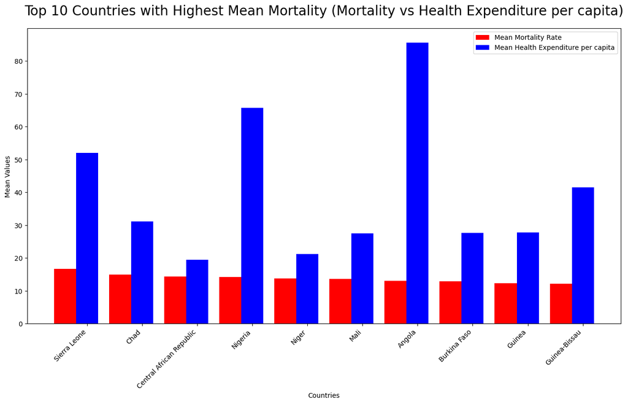

```python
# Sort the DataFrame by 'Mortality' in descending order and select the top 10
top_10_mortality = grouped_df.sort_values(by='Mortality', ascending=False).head(10)

# Set the positions for the bars
bar_width = 0.40
r1 = np.arange(len(top_10_mortality))
r2 = [x + bar_width for x in r1]

# Plot side-by-side bar chart for the top 10 highest mortality countries
plt.figure(figsize=(16, 8))

plt.bar(r1, top_10_mortality['Mortality'], width=bar_width, label='Mean Mortality Rate', color='red')
plt.bar(r2, top_10_mortality['Health Expenditure'], width=bar_width, label='Mean Health Expenditure per capita', color='blue')

plt.xlabel('Countries')
plt.ylabel('Mean Values')
plt.title('Top 10 Countries with Highest Mean Mortality (Mortality vs Health Expenditure per capita)', fontsize=20, pad=20)
plt.xticks([r + bar_width for r in range(len(top_10_mortality))], top_10_mortality['Countries'], rotation=45, ha='right')
plt.legend()
plt.show()
```

# Top 10 Countries with Highest Mean Mortality (Mortality vs Health Expenditure per capita)

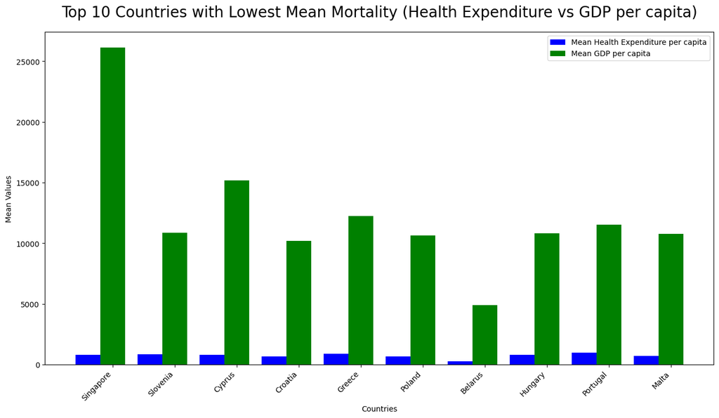

```python
# Sort the DataFrame by 'Mortality' in descending order and select the top 10
bottom_10_mortality = grouped_df.sort_values(by='Mortality', ascending=True).head(10)

# Set the positions for the bars
bar_width = 0.40
r1 = np.arange(len(bottom_10_mortality))
r2 = [x + bar_width for x in r1]

# Plot side-by-side bar chart for the top 10 highest mortality countries
plt.figure(figsize=(16, 8))

plt.bar(r1, bottom_10_mortality['Health Expenditure'], width=bar_width, label='Mean Health Expenditure per capita', color='blue')
plt.bar(r2, bottom_10_mortality['GDP'], width=bar_width, label='Mean GDP per capita', color='green')

plt.xlabel('Countries')
plt.ylabel('Mean Values')
plt.title('Top 10 Countries with Lowest Mean Mortality (Health Expenditure vs GDP per capita)', fontsize=20, pad=20)
plt.xticks([r + bar_width for r in range(len(bottom_10_mortality))], bottom_10_mortality['Countries'], rotation=45, ha='right')
plt.legend()
plt.show()
```

# Top 10 Countries with Lowest Mean Mortality (Health Expenditure vs GDP per capita)

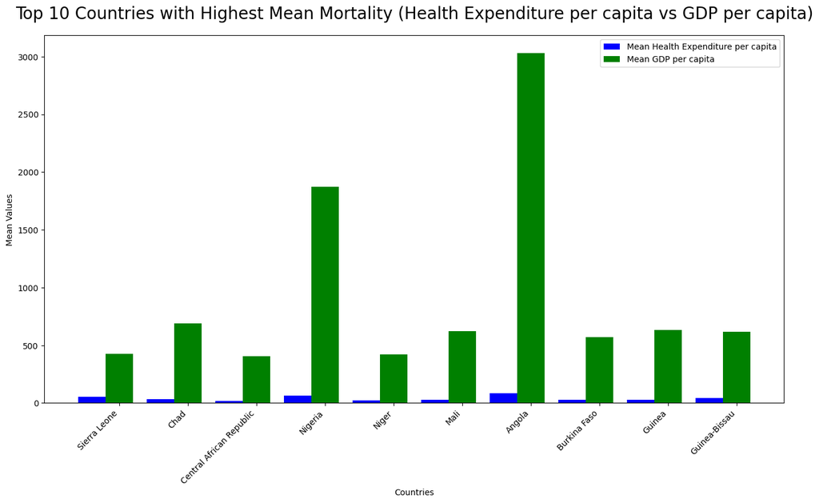

```python
# Sort the DataFrame by 'Mortality' in descending order and select the top 10
top_10_mortality = grouped_df.sort_values(by='Mortality', ascending=False).head(10)

# Set the positions for the bars
bar_width = 0.40
r1 = np.arange(len(top_10_mortality))
r2 = [x + bar_width for x in r1]

# Plot side-by-side bar chart for the top 10 highest mortality countries
plt.figure(figsize=(16, 8))

plt.bar(r1, top_10_mortality['Health Expenditure'], width=bar_width, label='Mean Health Expenditure per capita', color='blue')
plt.bar(r2, top_10_mortality['GDP'], width=bar_width, label='Mean GDP per capita', color='green')


plt.xlabel('Countries')
plt.ylabel('Mean Values')
plt.title('Top 10 Countries with Highest Mean Mortality (Health Expenditure per capita vs GDP per capita)', fontsize=20, pad=20)
plt.xticks([r + bar_width for r in range(len(top_10_mortality))], top_10_mortality['Countries'], rotation=45, ha='right')
plt.legend()
plt.show()
```

# Top 10 Countries with Highest Mean Mortality (Health Expenditure vs GDP per capita)

- The average child mortality rate for children under 5 in these countries is approximately 14.235 per 1000.
- The average GDP per capita for these countries is USD 928.32.
- These countries spend around USD 39.965 per capita on healthcare.  
  Conclusion: These countries, with the highest average mortality rates, have very low income and spend very little on healthcare.

```python
# Define the custom order for the 'Income Class' column
custom_order = ['Low', 'Lower Middle', 'Upper Middle', 'High']

# Convert 'Income Class' to a categorical variable with the custom order
merged_df['Income Class'] = pd.Categorical(merged_df['Income Class'], categories=custom_order, ordered=True)
```

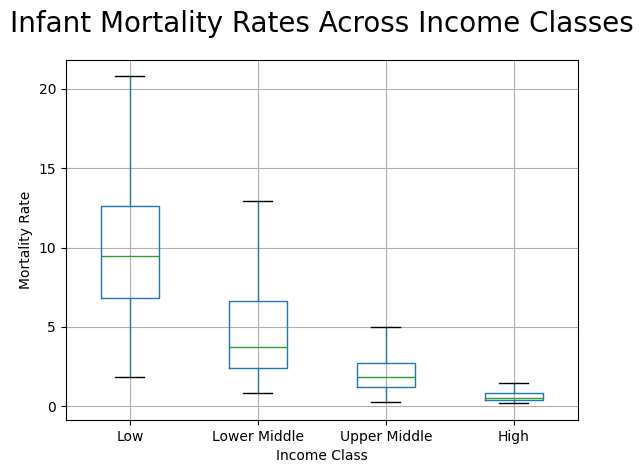

```python
# Boxplot for Mortality
plt.figure(figsize=(12, 6))
merged_df.boxplot(column='Mortality', by='Income Class', showfliers=False)
plt.title('Infant Mortality Rates Across Income Classes', fontsize=20, pad=20)
plt.suptitle('')  # Remove default title
plt.xlabel('Income Class')
plt.ylabel('Mortality Rate')
plt.show()
```

# Infant Mortality Rates Across Income Classes

- The low-income class countries exhibit the highest infant mortality rates around 7-13 per 1000, and the data indicates a considerable dispersion in mortality rates within this income class.
- The lower-middle-class countries demonstrate a significant decrease in their infant mortality rate, ranging from around 3 to 6 per 1000 live births, compared to the low-income class.
- The upper-middle-class countries exhibit an even lower infant mortality rate, ranging from 2 to 3 per 1000 live births, surpassing the lower-middle-class countries.
- The high-income class countries demonstrate the lowest infant mortality rates, hovering around 1 per 1000 live births.  
  Conclusion: The trend indicates that as countries progress in income, there is a notable reduction in infant mortality rates, showcasing an association between economic development and improved infant health outcomes.

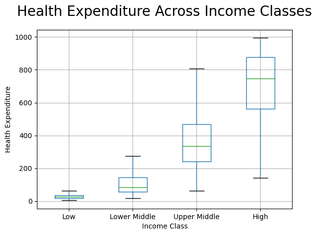

```python
# Boxplot for Health Expenditure
plt.figure(figsize=(12, 6))
merged_df.boxplot(column='Health Expenditure', by='Income Class', showfliers=False)
plt.title('Health Expenditure Across Income Classes', fontsize=20, pad=20)
plt.suptitle('')
plt.xlabel('Income Class')
plt.ylabel('Health Expenditure')
plt.show()
```

# Health Expenditure Across Income Classes

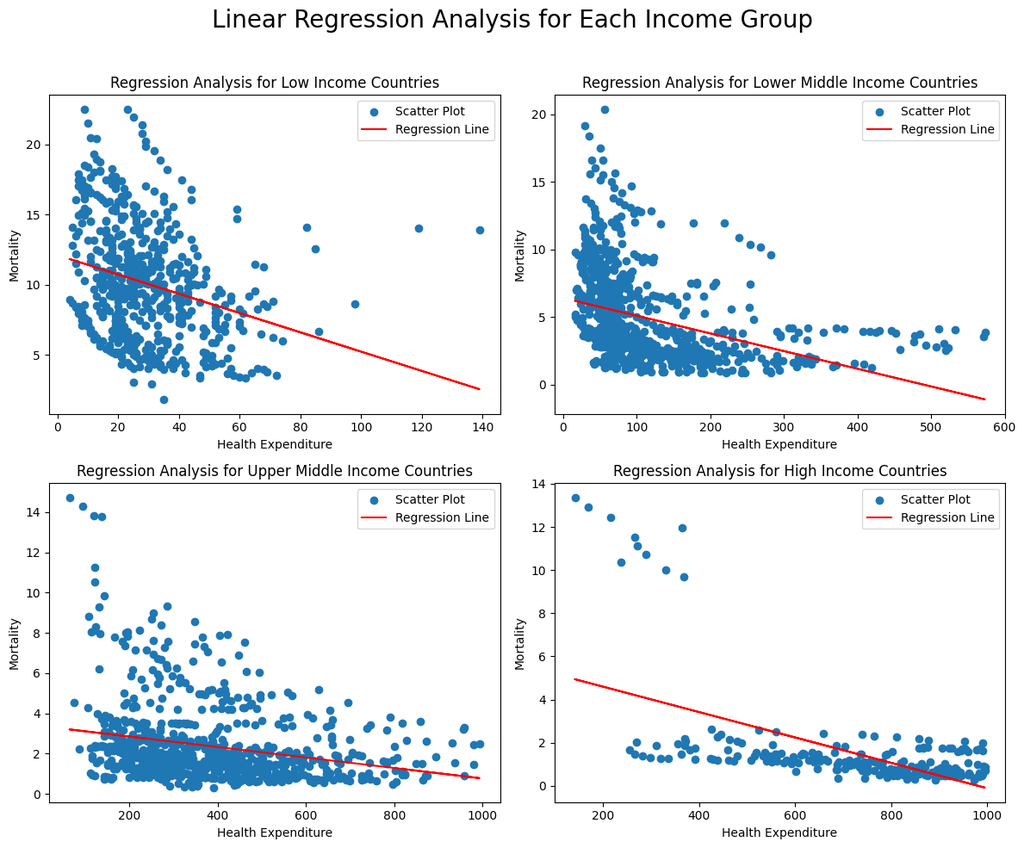

```python
# Function for linear regression analysis
def linear_regression_analysis(data, income_group, ax):
    # Filter data for the specific income group
    subset_data = data[data['Income Class'] == income_group].dropna()

    # Extract independent variable (X) and dependent variable (y)
    X = subset_data['Health Expenditure'].values
    y = subset_data['Mortality'].values

    # Perform linear regression using polyfit
    m, c = np.polyfit(X, y, deg=1)

    # Plot the scatter plot and regression line
    ax.scatter(X, y, label='Scatter Plot')
    ax.plot(X, m * X + c, 'r', label='Regression Line')

    # Set labels and title
    ax.set_xlabel('Health Expenditure')
    ax.set_ylabel('Mortality')
    ax.set_title(f'Regression Analysis for {income_group} Income Countries')
    ax.legend()

# Create a 2x2 grid of subplots
fig, axs = plt.subplots(2, 2, figsize=(12, 10))
fig.suptitle('Linear Regression Analysis for Each Income Group', fontsize=20)

# Perform linear regression analysis for each income group
income_groups = merged_df['Income Class'].unique().dropna()
for i, income_group in enumerate(income_groups):
    row, col = divmod(i, 2)
    linear_regression_analysis(merged_df, income_group, axs[row, col])

# Adjust layout
plt.tight_layout(rect=[0, 0, 1, 0.96])

# Show the plots
plt.show()
```